# TOPSIS and other MCDA methods as the decision layer

Annice Najafi

# Purpose

The MCDA baseline of the paper (Section 4.9) ranks the five corrective actions with TOPSIS, the decision rule of the companion HMM pipeline. A reader may ask whether the gap between this baseline and the POMDP is specific to TOPSIS. This notebook keeps everything else in the MCDA controller fixed (the five criteria and their weights, the exponential smoothing of the decoder labels, the Nominal override and the 0.5 s dwell time) and replaces only the ranking method with three widely used methods from the RMCDA package, each from a different family (additive weighting, compromise ranking and outranking):

| Method | RMCDA function | Score used (higher = better) |
| --- | --- | --- |
| TOPSIS (paper) | `apply.TOPSIS` | closeness to the ideal solution |
| SAW (simple additive weighting) | `apply.SAW` | weighted sum of the normalised criteria |
| VIKOR | `apply.VIKOR` | $-Q_i$ (VIKOR ranks by smallest $Q_i$, with $\nu = 0.5$) |
| PROMETHEE II | `apply.PROMETHEE` | net outranking flow |

All controllers are evaluated with the per-sample simulator of the paper (`R/sim_persample.R`): trajectories of 20 s start in Nominal, and trajectory $n$ of every method uses `set.seed(700000 + n)`, the seeds of Table 5. The methods therefore face the same random numbers, and their returns can be compared pairwise.

```r
source(file.path(root, "R", "paths.R"))
suppressPackageStartupMessages({ load_core(); library(RMCDA); library(ggplot2); library(scales) })
```

[output not shown]

[output not shown]

# Decision matrix

The criteria are those of `mcda_topsis_action()` in `R/sim_persample.R` (Supplementary Section S5.6). Three benefit criteria depend on the smoothed label distribution $\hat p = (\hat p_N, \hat p_S, \hat p_D, \hat p_R)$; the stability penalty and the action cost are fixed per action. The paper’s TOPSIS call treats every column as a benefit and enters the two costs as negative numbers. VIKOR and PROMETHEE in RMCDA make the same assumption, so they receive the same matrix. SAW takes the costs as positive numbers together with `beneficial.vector = 1:3`.

```r
mcda_actions <- c("DwSensorA", "DwSensorB", "IncFilter", "ReidentPlant", "BiasCorrect")
stability_penalty <- c(0.08, 0.08, 0.05, 0.15, 0.12)
action_cost       <- c(0.10, 0.10, 0.15, 0.40, 0.25)
mcda_weights      <- c(0.35, 0.25, 0.15, 0.10, 0.15)

benefit_criteria <- function(p) {
  pN <- p[1]; pS <- p[2]; pD <- p[3]; pR <- p[4]
  sensor_n <- pS; plant_n <- pD; drift_n <- pR; kpi_n <- 1 - pN; noise_n <- sensor_n
  cbind(KPI_gain = c(pS * kpi_n * sensor_n * 1.2, pS * kpi_n * sensor_n * 0.6,
                     pS * kpi_n * noise_n, pD * kpi_n * plant_n,
                     (pR + 0.5 * pD) * kpi_n * (drift_n + 0.3 * plant_n)),
        Module_gain = c(pS * sensor_n * 1.2, pS * sensor_n * 0.6, pS * sensor_n * noise_n,
                        pD * plant_n, (pR + 0.5 * pD) * (drift_n + 0.3 * plant_n)),
        Drift_gain = c(pS * drift_n * 1.1, pS * drift_n * 0.7, pS * drift_n * 0.6,
                       pD * drift_n * 0.4, (pR + 0.2 * pS) * drift_n))
}
dm_negcost <- function(p) {   # costs as negative benefits (TOPSIS, VIKOR, PROMETHEE)
  m <- cbind(benefit_criteria(p), Stability = -stability_penalty, Cost = -action_cost)
  rownames(m) <- mcda_actions; m
}
dm_poscost <- function(p) {   # costs as positive values, with beneficial.vector = 1:3
  m <- cbind(benefit_criteria(p), Stability = stability_penalty, Cost = action_cost)
  rownames(m) <- mcda_actions; m
}

w <- mcda_weights
scorers <- list(
  "TOPSIS"       = function(p) as.numeric(apply.TOPSIS(dm_negcost(p), w = w)),
  "SAW"          = function(p) as.numeric(apply.SAW(dm_poscost(p), w, 1:3)[[1]]),
  "VIKOR"        = function(p) -as.numeric(apply.VIKOR(dm_negcost(p), w)[[2]][mcda_actions]),
  "PROMETHEE II" = function(p) as.numeric(apply.PROMETHEE(dm_negcost(p), w)[[3]])
)
```

Each score is turned into an action in the same way as in the paper’s controller. If the scores are undefined, the controller applies NoAction. This happens with every method when a benefit column is zero for all five actions, for example before the first Drift label has been decoded, because each method normalises the columns. If the smoothed probability of Nominal exceeds 0.75, the controller also applies NoAction.

```r
mcda_action_with <- function(scorer) function(p) {
  sc <- tryCatch(suppressWarnings(scorer(p)), error = function(e) rep(NA_real_, 5))
  desired <- if (all(!is.finite(sc))) "NoAction" else mcda_actions[which.max(sc)]
  if ((1 - p[1]) < 0.25 && p[1] > 0.75) desired <- "NoAction"
  desired
}
```

As a check, the TOPSIS version reproduces `mcda_topsis_action()` of the paper on 5,000 random label distributions:

```r
set.seed(1)
P <- matrix(rexp(4 * 5000), ncol = 4); P <- P / rowSums(P)
P[sample(5000, 1000), 4] <- 0; P <- P / rowSums(P)   # include distributions without Drift mass
topsis_act <- mcda_action_with(scorers[["TOPSIS"]])
all(apply(P, 1, topsis_act) == apply(P, 1, mcda_topsis_action))
```

```
[1] TRUE
```

How often does each method choose the same action as TOPSIS on these distributions?

```r
acts <- sapply(names(scorers), function(m) apply(P, 1, mcda_action_with(scorers[[m]])))
round(colMeans(acts == acts[, "TOPSIS"]), 3)
```

```
      TOPSIS          SAW        VIKOR PROMETHEE II
       1.000        0.852        0.865        0.863
```

# Closed-loop comparison

The controller below is `ctl_mcda()` of `R/sim_persample.R` with the ranking step passed in. The simulation of the four methods takes several minutes; the results are cached in `output/analyses/mcda_methods_runs.rds`. Delete that file to re-run them.

```r
ctl_mcda_with <- function(choose, dwell_sec = mcda_dwell_time, alpha_ema = 0.3) {
  list(init = function(s0, O_true) {
         e <- new.env(); e$p <- numeric(K)
         e$p[sample.int(K, 1L, prob = O_true[s0, ])] <- 1
         e$a <- "NoAction"; e$t_sw <- 0; e
       },
       act = function(st, s) st$a,
       update = function(st, a, z, t) {
         ind <- numeric(K); ind[z] <- 1
         st$p <- alpha_ema * ind + (1 - alpha_ema) * st$p; st$p <- st$p / sum(st$p)
         want <- choose(st$p)
         if (want != st$a && (t - st$t_sw) >= dwell_sec - 1e-9) { st$a <- want; st$t_sw <- t }
         st
       })
}

mismatch_rate <- function(tr, mdp_policy, T_end) {   # as in analyses/table5_final.R
  n <- length(tr$times); wrong <- 0
  for (i in seq_len(n - 1))
    if (tr$actions[i] != mdp_policy[states[tr$states[i]]]) wrong <- wrong + (tr$times[i + 1] - tr$times[i])
  if (tr$actions[n] != mdp_policy[states[tr$states[n]]]) wrong <- wrong + (T_end - tr$times[n])
  wrong / T_end
}
```

```r
N <- nq(500, 50); T_end <- 20; seed0 <- 700000
cache <- out_path("analyses", "mcda_methods_runs.rds")
if (file.exists(cache) && identical(readRDS(cache)$N, N)) {
  runs <- readRDS(cache)$runs
} else {
  runs <- lapply(names(scorers), function(m) {
    ctl <- ctl_mcda_with(mcda_action_with(scorers[[m]]))
    r <- t(sapply(seq_len(N), function(n) {
      set.seed(seed0 + n)
      tr <- sim_ps(ctl, A, O_mat, s0 = 1L, T_end = T_end)
      c(ret = tr$disc_return, frac = frac_in_nominal(tr, T_end),
        mism = mismatch_rate(tr, vi$policy, T_end))
    }))
    data.frame(method = m, n = seq_len(N), r)
  })
  names(runs) <- names(scorers)
  saveRDS(list(N = N, runs = runs), cache)
}
```

The TOPSIS runs use the seeds of Table 5, so their returns must equal the first 500 MCDA returns of `analyses/table5_final.R`:

```r
t5 <- out_path("table5_final", "returns_per_trajectory.csv")
if (file.exists(t5)) {
  ref <- read.csv(t5, check.names = FALSE)[["MCDA (TOPSIS)"]][seq_len(N)]
  isTRUE(all.equal(runs[["TOPSIS"]]$ret, ref))
} else "Table 5 output not found (run Rscript run_all.R --only=table5)"
```

```
[1] TRUE
```

# Results

```r
summ <- do.call(rbind, lapply(runs, function(d) data.frame(
  Method = d$method[1], MeanReturn = mean(d$ret), SE = sd(d$ret) / sqrt(nrow(d)),
  FracNominal = mean(d$frac), MismatchPct = 100 * mean(d$mism))))
diffs <- do.call(rbind, lapply(names(runs), function(m) {
  d <- runs[[m]]$ret - runs[["TOPSIS"]]$ret
  p <- if (m == "TOPSIS" || all(d == 0)) NA_real_ else
    suppressWarnings(wilcox.test(d, mu = 0, exact = FALSE)$p.value)
  data.frame(Method = m, DiffVsTOPSIS = mean(d), DiffSE = sd(d) / sqrt(length(d)), Wilcoxon_p = p)
}))
summ <- merge(summ, diffs, by = "Method")
summ <- summ[order(-summ$MeanReturn), ]
summ$Wilcoxon_p_Holm <- p.adjust(summ$Wilcoxon_p, method = "holm")
knitr::kable(summ, digits = c(0, 1, 2, 3, 1, 1, 2, 4, 4), row.names = FALSE,
             caption = sprintf("Mean discounted return over %d trajectories of 20 s. DiffVsTOPSIS: mean paired difference in return from TOPSIS (same seeds); Wilcoxon signed-rank p-values, Holm-adjusted over the three comparisons.", N))
```

Mean discounted return over 500 trajectories of 20 s. DiffVsTOPSIS: mean paired difference in return from TOPSIS (same seeds); Wilcoxon signed-rank p-values, Holm-adjusted over the three comparisons.

| Method | MeanReturn | SE | FracNominal | MismatchPct | DiffVsTOPSIS | DiffSE | Wilcoxon_p | Wilcoxon_p_Holm |
| --- | --- | --- | --- | --- | --- | --- | --- | --- |
| VIKOR | 7.7 | 1.39 | 0.584 | 63.7 | 0.1 | 0.07 | 0.0677 | 0.2032 |
| PROMETHEE II | 7.6 | 1.39 | 0.583 | 63.8 | 0.1 | 0.09 | 0.2080 | 0.4159 |
| TOPSIS | 7.6 | 1.38 | 0.575 | 64.1 | 0.0 | 0.00 | NA | NA |
| SAW | 7.5 | 1.39 | 0.582 | 63.9 | 0.0 | 0.09 | 0.8324 | 0.8324 |

For reference, the other policies of Table 5 (2,000 trajectories each):

```r
tb_file <- out_path("table5_final", "PolicySummaryTable.csv")
ref_pol <- c("Optimal MDP", "POMDP (PBVI)", "Myopic belief", "MCDA (TOPSIS)", "No Intervention")
tb <- if (file.exists(tb_file)) read.csv(tb_file) else NULL
if (!is.null(tb)) knitr::kable(tb[tb$Policy %in% ref_pol, c("Policy", "MeanReward", "SEReward", "FracNominal", "MismatchPct")],
                               digits = c(0, 1, 2, 3, 1), row.names = FALSE)
```

| Policy | MeanReward | SEReward | FracNominal | MismatchPct |
| --- | --- | --- | --- | --- |
| Optimal MDP | 96.4 | 0.02 | 0.876 | 0.0 |
| POMDP (PBVI) | 63.2 | 0.20 | 0.729 | 24.8 |
| Myopic belief | 63.0 | 0.20 | 0.728 | 24.9 |
| MCDA (TOPSIS) | 8.6 | 0.68 | 0.571 | 64.1 |
| No Intervention | -7.0 | 0.78 | 0.212 | 78.8 |

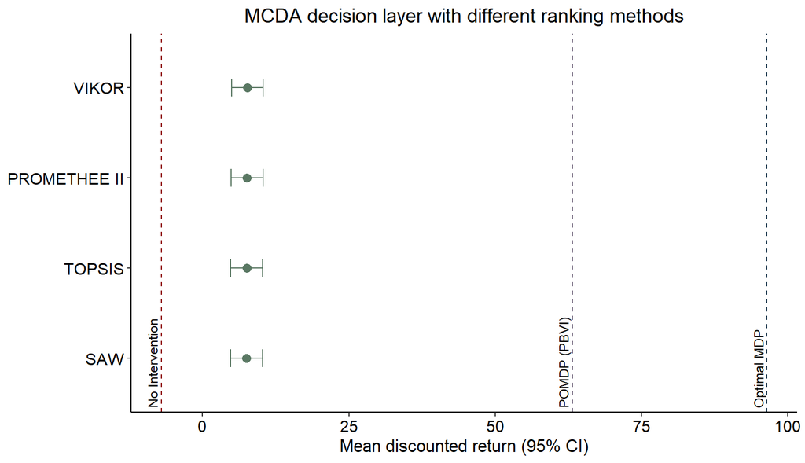

```r
summ$Method <- factor(summ$Method, levels = rev(summ$Method))
p <- ggplot(summ, aes(MeanReturn, Method)) +
  geom_errorbarh(aes(xmin = MeanReturn - 1.96 * SE, xmax = MeanReturn + 1.96 * SE),
                 height = 0.2, colour = "#5A7863") +
  geom_point(size = 2.6, colour = "#5A7863") +
  labs(x = "Mean discounted return (95% CI)", y = NULL,
       title = "MCDA decision layer with different ranking methods") +
  theme(panel.grid.major = element_blank(), panel.grid.minor = element_blank(),
        panel.background = element_blank(), axis.line = element_line(colour = "black"),
        plot.title = element_text(hjust = 0.5, size = 14),
        axis.text = element_text(size = 11.5, colour = "black"), axis.title = element_text(size = 12.5))
if (!is.null(tb)) {
  refs <- tb[tb$Policy %in% c("Optimal MDP", "POMDP (PBVI)", "No Intervention"), ]
  p <- p + geom_vline(data = refs, aes(xintercept = MeanReward), linetype = "dashed",
                      colour = c("#213C51", "#574964", "darkred")[match(refs$Policy,
                               c("Optimal MDP", "POMDP (PBVI)", "No Intervention"))]) +
    geom_text(data = refs, aes(x = MeanReward, y = 0.45, label = Policy), inherit.aes = FALSE,
              angle = 90, hjust = 0, vjust = -0.4, size = 3.3)
}
p
```

# Reading the results

The table and the plot answer one question: does any of these ranking rules, given the same smoothed labels, criteria and weights, close the gap to the POMDP? All of them score each decision epoch on its own and ignore the regime dynamics and the reliability of the decoder, so differences between them come only from how they aggregate the five criteria. The paired differences show whether a method differs from TOPSIS by more than the Monte Carlo noise, and the dashed lines place every method relative to the POMDP, the MDP and No Intervention.

In this run the mean returns of the four methods lie between 7.5 and 7.7, none of the three alternatives differs from TOPSIS at the 5% level after the Holm adjustment (smallest adjusted p-value 0.20), and all of them remain far below the POMDP. Although the methods pick a different action from TOPSIS on some label distributions, in closed loop they lead to almost the same behaviour. The gap reported in the paper therefore reflects the per-epoch, label-driven design of the MCDA controller, and the choice of TOPSIS within that design has little effect on it.